# Proposal —- The state of 2019-ncov’s development worldwide and its impact on China

### Author:LiuXiaohan SunRongxue WangFan ChengHongyu

### 2020/3/31

### 1.Research Background

Over the past months,the COVID-19 has made it’s way around China with a strong impact of our life and study. Because of population movements, the disease began to spread rapidly throughout the world in March.  
The COVID-19 has become a common concern of people all over the world.The chart below shows the number of infected people in nine countries.

|  | country | infectionpopulation | time |
| --- | --- | --- | --- |
| 1 | US | 16.38 | 3.31 |
| 2 | Italy | 10.17 | 3.31 |
| 3 | Spain | 8.80 | 3.31 |
| 4 | China | 8.25 | 3.31 |
| 5 | Germany | 6.69 | 3.31 |
| 6 | France | 4.52 | 3.31 |
| 7 | Iran | 4.15 | 3.31 |
| 8 | Switzerland | 1.60 | 3.31 |
| 9 | Korea | 0.96 | 3.31 |

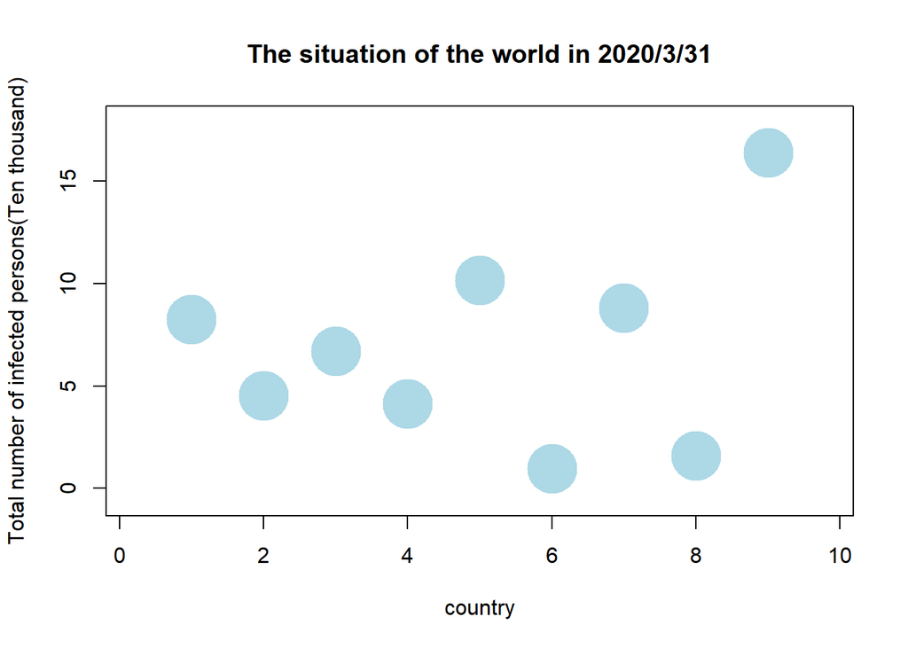

The daily number of new infections in China in March is shown in the chart below:

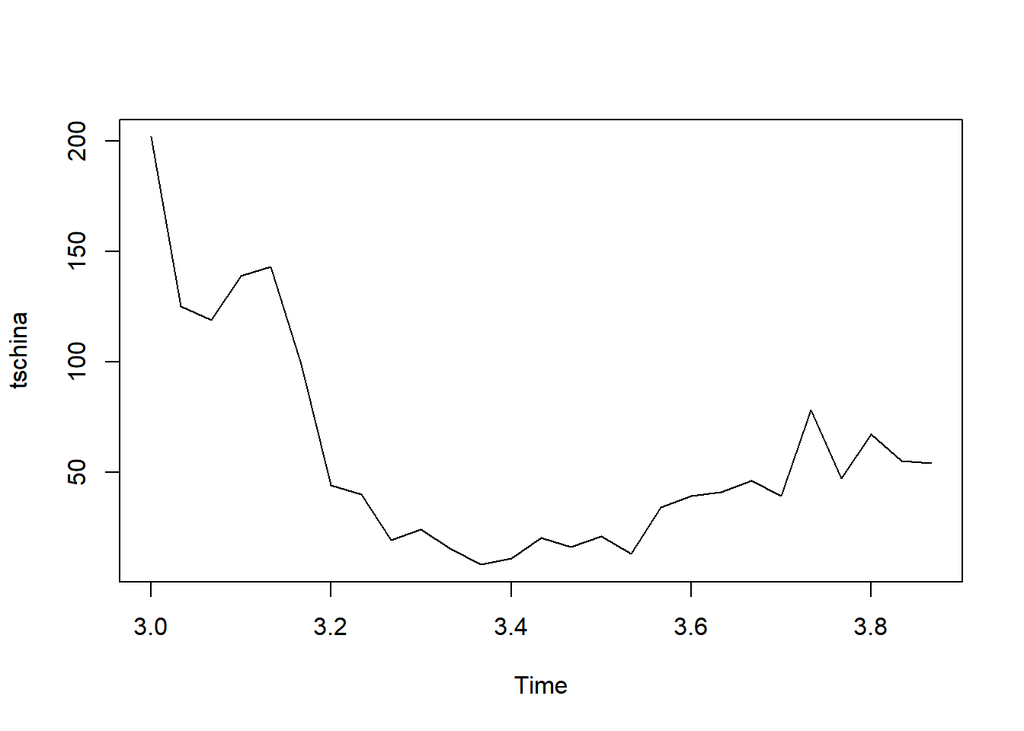

### 2. Methods and Procedures

#### 2.1 Methods

The most traditional approach to the spread of an epidemic is the SER model,We will combine knowledge of statistics and what we have learned to design a new model to study this problem.

#### 2.2 Procedures

1.Analysis of the international situation about the COVID-19.

We will take Italy as an example to analyze the current situation abroad and Using models to predict change point in Italian inflexion populations.

2.Using imported patient data to predict the number of future infections in China.

### 3. Data

All of our datasets are come from website:

① National Health Commission of the People’s Republic of China

http://www.nhc.gov.cn/xcs/yqtb/list_gzbd.shtml

② World Health Organization

https://www.who.int/

③C enter for Disease Control and Prevention

https://www.cdc.gov/coronavirus/2019-ncov/index.html

### 4. Problems

① Model

We are not familiar with the SER modal,so we need to spend more time to study it or design our own new model with statistic knowledge.

② Ability of R coding

Next we’ll use R to do our job,but it is a little bit difficult for us to use it as experts.And we will learn more by exercising.

③ Communication

The companions are not in the school, we are very difficult to discuss the work details togetherand just rely on the network communication tools.